# Introduction to Data Science - Method and Tools

[figure not shown]

### The work was written by:

Dolev Danenberg

Baruh Shalumov

### The research question we will focus on is:

**How the Twin Towers Disaster Affected Aviation in the USA ?**

### The purpose of our research:

Our goal in the project is to understand how the Twin Towers attack affected the U.S. aviation world.  
The information we use is the dataset we found at [kaggle (USA Airport Dataset).](https://www.kaggle.com/flashgordon/usa-airport-dataset)  
This dataset is a record of 3.5 Million + US Domestic Flights from 1990 to 2009. It has been taken from OpenFlights website which has a huge database of different traveling mediums across the globe.  
With his help we can produce a snapshot of domestic flights in the US before the attack and view the amount of flights, people, planes and more, and on the other hand we can see the snapshot after the attack.  
We are assuming that there will inevitably be damage to the number of flights, people flying and more for security reasons interrupted by the US after the big attack.

### What's in it?

Here is some info about the attributes present in the dataset:

1. Origin_airport - Three letter airport code of the origin airport
2. Destination_airport - Three letter airport code of the destination airport
3. Origin_city - Origin city name
4. Destination_city - Destination city name
5. Passengers - Number of passengers transported from origin to destination
6. Seats - Number of seats available on flights from origin to destination
7. Flights - Number of flights between origin and destination (multiple records for one month, many with flights> 1)
8. Distance - Distance (to nearest mile) flow between origin and destination
9. Fly_date - The date (yyyymm) of flight
10. Origin_population - Origin city's population as reported by US Census
11. Destination_population - Destination city's population as reported by US Census

### Introduction

1. View basic information
2. Viewing Status Before 2001
3. Viewing Status in 2001
4. Viewing Status After 2001
5. Summary
6. Conclusions

### Intentional questions

1. What is the amount of flights departing each year
2. What is the amount of people actually flying in relation to the number of seats on flights
3. What is the amount of passengers in the 3 popular in New york - the main focus of the attack

**The directed questions will appear in all sections mentioned in the introduction**

### Legend

- **Purple** - Headlines explaining what the purpose is at this stage
- **Red** - notes
- **Green** - Conclusions of the current section

## Basic information

#### This area will contain all the imports required for the project.

```python
import sys
# !{sys.executable} -m pip install numpy
# !{sys.executable} -m pip install pandas
# !{sys.executable} -m pip install matplotlib
# !{sys.executable} -m pip install datetime
# !{sys.executable} -m pip install seaborn
# !{sys.executable} -m pip install requests
# !{sys.executable} -m pip install bs4
# !{sys.executable} -m pip install regex
# !{sys.executable} -m pip install plotly
```

```python
import re
import datetime
import requests
import numpy as np
import pandas as pd
import seaborn as sns
import plotly.express as px
import plotly.graph_objs as go
import matplotlib.pyplot as plt
from bs4 import BeautifulSoup
from plotly.offline import download_plotlyjs, init_notebook_mode, plot, iplot
```

#### We will read our data content and enter a local variable called "myLocalDataSet".

```python
myLocalDataSet = pd.read_csv("Airports2.csv")
```

```python
myLocalDataSet
```

|  | Origin_airport | Destination_airport | Origin_city | Destination_city | Passengers | Seats | Flights | Distance | Fly_date | Origin_population | Destination_population | Org_airport_lat | Org_airport_long | Dest_airport_lat | Dest_airport_long |
| --- | --- | --- | --- | --- | --- | --- | --- | --- | --- | --- | --- | --- | --- | --- | --- |
| 0 | MHK | AMW | Manhattan, KS | Ames, IA | 21 | 30 | 1 | 254 | 2008-10-01 | 122049 | 86219 | 39.140999 | -96.670799 | NaN | NaN |
| 1 | EUG | RDM | Eugene, OR | Bend, OR | 41 | 396 | 22 | 103 | 1990-11-01 | 284093 | 76034 | 44.124599 | -123.211998 | 44.254101 | -121.150001 |
| 2 | EUG | RDM | Eugene, OR | Bend, OR | 88 | 342 | 19 | 103 | 1990-12-01 | 284093 | 76034 | 44.124599 | -123.211998 | 44.254101 | -121.150001 |
| 3 | EUG | RDM | Eugene, OR | Bend, OR | 11 | 72 | 4 | 103 | 1990-10-01 | 284093 | 76034 | 44.124599 | -123.211998 | 44.254101 | -121.150001 |
| 4 | MFR | RDM | Medford, OR | Bend, OR | 0 | 18 | 1 | 156 | 1990-02-01 | 147300 | 76034 | 42.374199 | -122.873001 | 44.254101 | -121.150001 |
| ... | ... | ... | ... | ... | ... | ... | ... | ... | ... | ... | ... | ... | ... | ... | ... |
| 3606798 | STL | TBN | St. Louis, MO | Fort Leonard Wood, MO | 281 | 969 | 51 | 119 | 2009-02-01 | 2828990 | 46457 | 38.748699 | -90.370003 | 37.741600 | -92.140701 |
| 3606799 | STL | TBN | St. Louis, MO | Fort Leonard Wood, MO | 245 | 1026 | 54 | 119 | 2009-11-01 | 2828990 | 46457 | 38.748699 | -90.370003 | 37.741600 | -92.140701 |
| 3606800 | STL | TBN | St. Louis, MO | Fort Leonard Wood, MO | 363 | 1273 | 67 | 119 | 2009-08-01 | 2828990 | 46457 | 38.748699 | -90.370003 | 37.741600 | -92.140701 |
| 3606801 | CGI | TBN | Cape Girardeau, MO | Fort Leonard Wood, MO | 2 | 19 | 1 | 146 | 2009-08-01 | 93712 | 46457 | 37.225300 | -89.570801 | 37.741600 | -92.140701 |
| 3606802 | FWA | OH1 | Fort Wayne, IN | Washington Court House, OH | 0 | 0 | 1 | 135 | 2003-09-01 | 398574 | 28133 | 40.978500 | -85.195099 | NaN | NaN |

3606803 rows × 15 columns

#### Displays all columns and column types in the file.

```python
myLocalDataSet.dtypes
```

```
Origin_airport             object
Destination_airport        object
Origin_city                object
Destination_city           object
Passengers                  int64
Seats                       int64
Flights                     int64
Distance                    int64
Fly_date                   object
Origin_population           int64
Destination_population      int64
Org_airport_lat           float64
Org_airport_long          float64
Dest_airport_lat          float64
Dest_airport_long         float64
dtype: object
```

#### Displays the amount of information in the file (in rows).

```python
numberOfRowsInCsv = myLocalDataSet.index.stop
print("The amount of information in the file (in rows) is", numberOfRowsInCsv)
```

```
The amount of information in the file (in rows) is 3606803
```

#### Describe method

Whenever I face a dataset I am unfamiliar with, my typical first step is to get a high level overview of its contents.  
The describe method gives such an overview of the DataFrame, and it shows the data type, the number of entries and missing values for each column. In addition, for each numerical column it also shows the mean, standard deviation, minimum and maximum values.  
All this is done with a single pass over the data!

```python
myLocalDataSet.describe()
```

|  | Passengers | Seats | Flights | Distance | Origin_population | Destination_population | Org_airport_lat | Org_airport_long | Dest_airport_lat | Dest_airport_long |
| --- | --- | --- | --- | --- | --- | --- | --- | --- | --- | --- |
| count | 3.606803e+06 | 3.606803e+06 | 3.606803e+06 | 3.606803e+06 | 3.606803e+06 | 3.606803e+06 | 3.599849e+06 | 3.599849e+06 | 3.599996e+06 | 3.599996e+06 |
| mean | 2.688910e+03 | 4.048297e+03 | 3.722890e+01 | 6.973190e+02 | 5.871502e+06 | 5.897982e+06 | 3.775029e+01 | -9.186178e+01 | 3.774091e+01 | -9.183433e+01 |
| std | 4.347617e+03 | 6.200871e+03 | 4.961970e+01 | 6.044165e+02 | 7.858062e+06 | 7.906127e+06 | 5.765453e+00 | 1.653773e+01 | 5.736556e+00 | 1.647228e+01 |
| min | 0.000000e+00 | 0.000000e+00 | 0.000000e+00 | 0.000000e+00 | 1.300500e+04 | 1.288700e+04 | 1.972140e+01 | -1.579220e+02 | 1.972140e+01 | -1.579220e+02 |
| 25% | 1.090000e+02 | 1.560000e+02 | 2.000000e+00 | 2.730000e+02 | 1.030597e+06 | 1.025470e+06 | 3.363670e+01 | -9.703800e+01 | 3.363670e+01 | -9.703800e+01 |
| 50% | 1.118000e+03 | 1.998000e+03 | 2.500000e+01 | 5.190000e+02 | 2.400193e+06 | 2.400193e+06 | 3.885210e+01 | -8.775240e+01 | 3.885210e+01 | -8.775240e+01 |
| 75% | 3.503000e+03 | 5.370000e+03 | 5.500000e+01 | 9.270000e+02 | 8.613622e+06 | 8.635706e+06 | 4.173260e+01 | -8.029060e+01 | 4.173260e+01 | -8.029060e+01 |
| max | 8.959700e+04 | 1.470620e+05 | 1.128000e+03 | 5.095000e+03 | 3.813959e+07 | 3.813959e+07 | 6.483750e+01 | -6.882810e+01 | 6.483750e+01 | -6.882810e+01 |

#### Let's start converting flight dates from object type to date type.

```python
myLocalDataSet['Fly_date'] =  pd.to_datetime(myLocalDataSet['Fly_date'], infer_datetime_format=True)
```

```python
myLocalDataSet.dtypes
```

```
Origin_airport                    object
Destination_airport               object
Origin_city                       object
Destination_city                  object
Passengers                         int64
Seats                              int64
Flights                            int64
Distance                           int64
Fly_date                  datetime64[ns]
Origin_population                  int64
Destination_population             int64
Org_airport_lat                  float64
Org_airport_long                 float64
Dest_airport_lat                 float64
Dest_airport_long                float64
dtype: object
```

## Status Before 2001

[figure not shown]

#### We will look at how many flights were up to 2001 by each year

```python
start_date = "01-01-1990"
end_date = "01-01-2001"
half_dataset_for_specific_dates = myLocalDataSet[(myLocalDataSet.Fly_date >= start_date) & (myLocalDataSet.Fly_date < end_date)]
Number_of_flights_per_year_before = half_dataset_for_specific_dates.Flights.groupby(half_dataset_for_specific_dates.Fly_date.dt.year).agg('sum')
Number_of_flights_per_year_before
```

```
Fly_date
1990    5097236
1991    5091717
1992    5267990
1993    5366248
1994    5650424
1995    6072590
1996    6203237
1997    6207832
1998    6252185
1999    6546752
2000    6826496
Name: Flights, dtype: int64
```

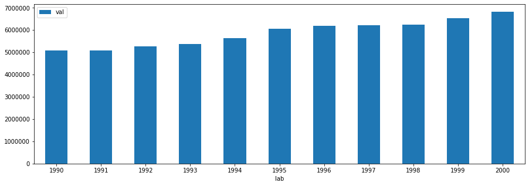

```python
df = pd.DataFrame({'lab':list(range(1990,2001)), 'val':Number_of_flights_per_year_before})
ax = df.plot.bar(x='lab', y='val', rot=0, figsize=(15,5))
```

#### We will show the difference between the number of passengers and the number of seats from 1990 to 2000 (inclusive)

```python
start_date = "01-01-1990"
end_date = "01-01-2001"
dataset_before_2001 = myLocalDataSet[(myLocalDataSet.Fly_date >= start_date) & (myLocalDataSet.Fly_date < end_date)]
```

```python
passengers_vs_seats_before_2001 = pd.DataFrame({'Passengers':dataset_before_2001['Passengers'].groupby(dataset_before_2001.Fly_date.dt.year).agg('sum'), 'Seats':dataset_before_2001['Seats'].groupby(dataset_before_2001.Fly_date.dt.year).agg('sum')})
passengers_vs_seats_before_2001
```

| Fly_date | Passengers | Seats |
| --- | --- | --- |
| 1990 | 370404412 | 666616024 |
| 1991 | 366689941 | 654367551 |
| 1992 | 383323302 | 672449552 |
| 1993 | 391096541 | 677315910 |
| 1994 | 426130721 | 701075444 |
| 1995 | 441706772 | 719218092 |
| 1996 | 467885967 | 727071586 |
| 1997 | 481929580 | 739532479 |
| 1998 | 491917421 | 740161001 |
| 1999 | 511338939 | 772402427 |
| 2000 | 533957069 | 792836097 |

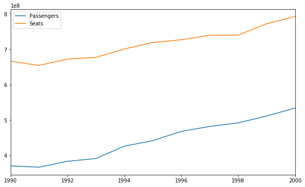

```python
passengers_vs_seats_before_2001_graph = pd.DataFrame({'Passengers': passengers_vs_seats_before_2001['Passengers'],'Seats': passengers_vs_seats_before_2001['Seats']}, index=list(range(1990,2001)))
lines = passengers_vs_seats_before_2001_graph.plot.line(figsize=(10,6))
```

According to the data so far, it is possible to understand the graph from 1990 to 2000, including an increase in the aviation world

## Status in 2001

[figure not shown]

#### Considered how many flights were total in 2001

```python
start_date = "01-01-2001"
end_date = "01-01-2002"
half_dataset_for_specific_dates = myLocalDataSet[(myLocalDataSet.Fly_date >= start_date) & (myLocalDataSet.Fly_date < end_date)]
Number_of_flights_per_year_in = half_dataset_for_specific_dates.Flights.groupby(half_dataset_for_specific_dates.Fly_date.dt.year).agg('sum')
```

```python
print("The number of flights in 2001 was", Number_of_flights_per_year_in.iloc[0], "flights")
```

```
The number of flights in 2001 was 6644524 flights
```

#### We will show the difference between the number of passengers and the number of seats from 2000 to 2002 (inclusive)

```python
start_date = "01-01-2000"
end_date = "01-01-2003"
dataset_in_2001 = myLocalDataSet[(myLocalDataSet.Fly_date >= start_date) & (myLocalDataSet.Fly_date < end_date)]
```

```python
passengers_vs_seats_in_2001 = pd.DataFrame({'Passengers':dataset_in_2001['Passengers'].groupby(dataset_in_2001.Fly_date.dt.year).agg('sum'), 'Seats':dataset_in_2001['Seats'].groupby(dataset_in_2001.Fly_date.dt.year).agg('sum')})
passengers_vs_seats_in_2001
```

| Fly_date | Passengers | Seats |
| --- | --- | --- |
| 2000 | 533957069 | 792836097 |
| 2001 | 497009692 | 759926795 |
| 2002 | 486028550 | 731404806 |

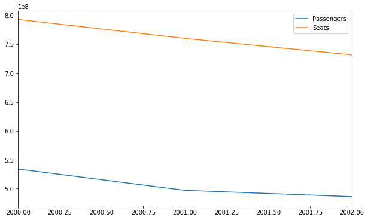

```python
passengers_vs_seats_in_2001_graph = pd.DataFrame({'Passengers': passengers_vs_seats_in_2001['Passengers'],'Seats': passengers_vs_seats_in_2001['Seats']}, index=list(range(2000,2003)))
lines = passengers_vs_seats_in_2001_graph.plot.line(figsize=(10,6))
```

## Status After 2001

[figure not shown]

```python
start_date = "01-01-2002"
end_date = "01-01-2010"
half_dataset_for_specific_dates = myLocalDataSet[(myLocalDataSet.Fly_date >= start_date) & (myLocalDataSet.Fly_date < end_date)]
Number_of_flights_per_year_after = half_dataset_for_specific_dates.Flights.groupby(half_dataset_for_specific_dates.Fly_date.dt.year).agg('sum')
Number_of_flights_per_year_after
```

```
Fly_date
2002    6788779
2003    8041912
2004    8441596
2005    8489778
2006    8130074
2007    8165862
2008    7782832
2009    7209239
Name: Flights, dtype: int64
```

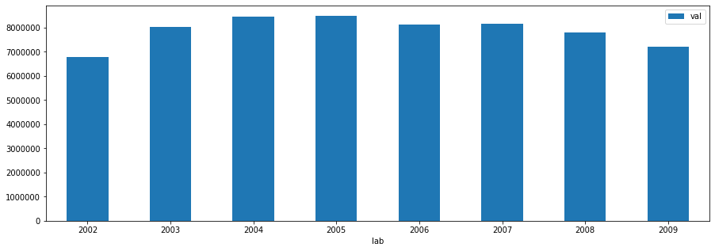

```python
df = pd.DataFrame({'lab':list(range(2002,2010)), 'val':Number_of_flights_per_year_after})
ax = df.plot.bar(x='lab', y='val', rot=0, figsize=(15,5))
```

#### We will show the difference between the number of passengers and the number of seats from 2002 to 2009 (inclusive)

```python
start_date = "01-01-2002"
end_date = "01-01-2010"
dataset_after_2001 = myLocalDataSet[(myLocalDataSet.Fly_date >= start_date) & (myLocalDataSet.Fly_date < end_date)]
```

```python
passengers_vs_seats_after_2001 = pd.DataFrame({'Passengers':dataset_after_2001['Passengers'].groupby(dataset_after_2001.Fly_date.dt.year).agg('sum'), 'Seats':dataset_after_2001['Seats'].groupby(dataset_after_2001.Fly_date.dt.year).agg('sum')})
passengers_vs_seats_after_2001
```

| Fly_date | Passengers | Seats |
| --- | --- | --- |
| 2002 | 486028550 | 731404806 |
| 2003 | 508988965 | 741917776 |
| 2004 | 546469416 | 776736457 |
| 2005 | 568207371 | 783089455 |
| 2006 | 564727445 | 752664340 |
| 2007 | 579257485 | 763818347 |
| 2008 | 554998719 | 738400196 |
| 2009 | 526301909 | 690406760 |

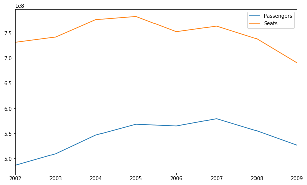

```python
passengers_vs_seats_after_2001_graph = pd.DataFrame({'Passengers': passengers_vs_seats_after_2001['Passengers'],'Seats': passengers_vs_seats_after_2001['Seats']}, index=list(range(2002,2010)))
lines = passengers_vs_seats_after_2001_graph.plot.line(figsize=(10,6))
```

## Summary

#### We will now connect the three sections to one big picture of the situation.

```python
start_date = "01-01-1990"
end_date = "01-01-2010"
Number_of_flights_per_year = myLocalDataSet.Flights.groupby(myLocalDataSet.Fly_date.dt.year).agg('sum')
Number_of_flights_per_year
```

```
Fly_date
1990    5097236
1991    5091717
1992    5267990
1993    5366248
1994    5650424
1995    6072590
1996    6203237
1997    6207832
1998    6252185
1999    6546752
2000    6826496
2001    6644524
2002    6788779
2003    8041912
2004    8441596
2005    8489778
2006    8130074
2007    8165862
2008    7782832
2009    7209239
Name: Flights, dtype: int64
```

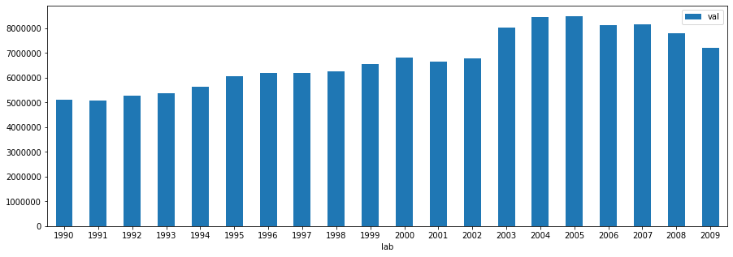

```python
df = pd.DataFrame({'lab':list(range(1990,2010)), 'val':Number_of_flights_per_year})
ax = df.plot.bar(x='lab', y='val', rot=0, figsize=(15,5))
```

#### The amount of people flying between 1990 and 2009 relative to total in those years (in percent).

```python
passengers_per_day = pd.pivot_table(data=myLocalDataSet, index='Fly_date', values='Passengers', aggfunc='sum').reset_index().rename(columns={'Passengers': 'total_passengers'})
```

```python
passengers_per_year = myLocalDataSet['Passengers'].groupby(myLocalDataSet.Fly_date.dt.year).agg('sum')
```

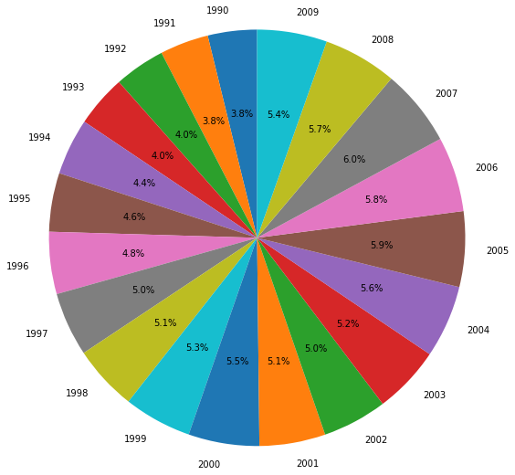

```python
labels = list(range(1990,2010))
sizes = list(passengers_per_year/passengers_per_year.sum()*100)

fig1, ax1 = plt.subplots(figsize=(9, 9))
ax1.pie(sizes, labels=labels, autopct='%1.1f%%', startangle=90)
ax1.axis('equal')
plt.show()
```

#### The number of people flying each year

```python
passengers = myLocalDataSet['Passengers'].groupby(myLocalDataSet.Fly_date.dt.year).agg('sum')
```

#### Number of seats that were on flights each year

```python
seats = myLocalDataSet['Seats'].groupby(myLocalDataSet.Fly_date.dt.year).agg('sum')
```

#### A table showing each year like the people who flew in relation to the number of seats that were

```python
passengers_vs_seats = pd.DataFrame({'Passengers':passengers, 'Seats':seats})
passengers_vs_seats
```

| Fly_date | Passengers | Seats |
| --- | --- | --- |
| 1990 | 370404412 | 666616024 |
| 1991 | 366689941 | 654367551 |
| 1992 | 383323302 | 672449552 |
| 1993 | 391096541 | 677315910 |
| 1994 | 426130721 | 701075444 |
| 1995 | 441706772 | 719218092 |
| 1996 | 467885967 | 727071586 |
| 1997 | 481929580 | 739532479 |
| 1998 | 491917421 | 740161001 |
| 1999 | 511338939 | 772402427 |
| 2000 | 533957069 | 792836097 |
| 2001 | 497009692 | 759926795 |
| 2002 | 486028550 | 731404806 |
| 2003 | 508988965 | 741917776 |
| 2004 | 546469416 | 776736457 |
| 2005 | 568207371 | 783089455 |
| 2006 | 564727445 | 752664340 |
| 2007 | 579257485 | 763818347 |
| 2008 | 554998719 | 738400196 |
| 2009 | 526301909 | 690406760 |

#### Graph showing the table visually

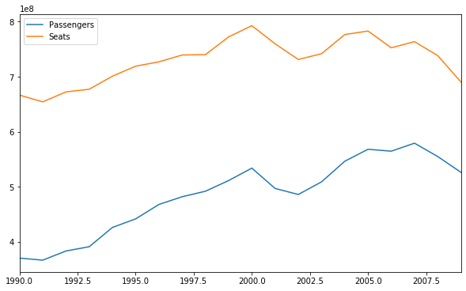

```python
passengers_vs_seats_graph = pd.DataFrame({'Passengers': passengers_vs_seats['Passengers'],'Seats': passengers_vs_seats['Seats']}, index=list(range(1990,2010)))
lines = passengers_vs_seats_graph.plot.line(figsize=(10,6))
```

```python
df_US=myLocalDataSet[['Origin_city','Origin_population']]
df_US=df_US.drop_duplicates()  #droping duplicate
df_US
```

|  | Origin_city | Origin_population |
| --- | --- | --- |
| 0 | Manhattan, KS | 122049 |
| 1 | Eugene, OR | 284093 |
| 4 | Medford, OR | 147300 |
| 9 | Seattle, WA | 5154164 |
| 14 | Portland, OR | 1534762 |
| ... | ... | ... |
| 3531679 | Logan, UT | 120837 |
| 3541526 | Laconia, NH | 61027 |
| 3543887 | Lawrence, KS | 114752 |
| 3577586 | New Iberia, LA | 75101 |
| 3600726 | Pueblo, CO | 134919 |

6736 rows × 2 columns

```python
df_US['Origin_city']=df_US['Origin_city'].str[-2:]
df_US = df_US.sort_values(by=['Origin_city'])
df_US = df_US.reset_index(drop=True)
df_US.head
```

```
<bound method NDFrame.head of      Origin_city  Origin_population
0             AK             311411
1             AK              14611
2             AK              14883
3             AK              14905
4             AK              83978
...          ...                ...
6731          WY              27947
6732          WY              39320
6733          WY              19190
6734          WY              37948
6735          WY              30587

[6736 rows x 2 columns]>
```

```python
State=df_US['Origin_city'].unique()
State
```

```
array(['AK', 'AL', 'AR', 'AZ', 'CA', 'CO', 'CT', 'DC', 'DE', 'FL', 'GA',
       'HI', 'IA', 'ID', 'IL', 'IN', 'KS', 'KY', 'LA', 'MA', 'MD', 'ME',
       'MI', 'MN', 'MO', 'MS', 'MT', 'NC', 'ND', 'NE', 'NH', 'NJ', 'NM',
       'NV', 'NY', 'OH', 'OK', 'OR', 'PA', 'RI', 'SC', 'SD', 'TN', 'TX',
       'UT', 'VA', 'VT', 'WA', 'WI', 'WV', 'WY'], dtype=object)
```

```python
State_popula=[]
for S_code in State:
    State_popula.append(df_US.loc[df_US['Origin_city'] == S_code, 'Origin_population'].sum()) #sum all together
State_popula
```

```
[9342827,
 50414426,
 27419818,
 91115137,
 1229996280,
 17109030,
 46359893,
 190595458,
 87397686,
 525938508,
 118776415,
 23045058,
 25341954,
 6751463,
 388583311,
 227740576,
 20093730,
 13916311,
 61911135,
 187669171,
 55906941,
 13930193,
 234336235,
 71924896,
 108589872,
 20768726,
 11217727,
 88522693,
 9215198,
 23953842,
 7512832,
 368706360,
 24508935,
 34164486,
 807884160,
 176449464,
 42387030,
 59561182,
 333105246,
 31100493,
 45052476,
 7786721,
 76701116,
 438531167,
 33072002,
 36499575,
 4485518,
 176847483,
 60588835,
 11862911,
 5487967]
```

```python
Wrong_data= pd.DataFrame({'State_code':State, 'State_population':State_popula})
Wrong_data
```

|  | State_code | State_population |
| --- | --- | --- |
| 0 | AK | 9342827 |
| 1 | AL | 50414426 |
| 2 | AR | 27419818 |
| 3 | AZ | 91115137 |
| 4 | CA | 1229996280 |
| 5 | CO | 17109030 |
| 6 | CT | 46359893 |
| 7 | DC | 190595458 |
| 8 | DE | 87397686 |
| 9 | FL | 525938508 |
| 10 | GA | 118776415 |
| 11 | HI | 23045058 |
| 12 | IA | 25341954 |
| 13 | ID | 6751463 |
| 14 | IL | 388583311 |
| 15 | IN | 227740576 |
| 16 | KS | 20093730 |
| 17 | KY | 13916311 |
| 18 | LA | 61911135 |
| 19 | MA | 187669171 |
| 20 | MD | 55906941 |
| 21 | ME | 13930193 |
| 22 | MI | 234336235 |
| 23 | MN | 71924896 |
| 24 | MO | 108589872 |
| 25 | MS | 20768726 |
| 26 | MT | 11217727 |
| 27 | NC | 88522693 |
| 28 | ND | 9215198 |
| 29 | NE | 23953842 |
| 30 | NH | 7512832 |
| 31 | NJ | 368706360 |
| 32 | NM | 24508935 |
| 33 | NV | 34164486 |
| 34 | NY | 807884160 |
| 35 | OH | 176449464 |
| 36 | OK | 42387030 |
| 37 | OR | 59561182 |
| 38 | PA | 333105246 |
| 39 | RI | 31100493 |
| 40 | SC | 45052476 |
| 41 | SD | 7786721 |
| 42 | TN | 76701116 |
| 43 | TX | 438531167 |
| 44 | UT | 33072002 |
| 45 | VA | 36499575 |
| 46 | VT | 4485518 |
| 47 | WA | 176847483 |
| 48 | WI | 60588835 |
| 49 | WV | 11862911 |
| 50 | WY | 5487967 |

The Data of the population is wrong the population is too big  
we can see that only in CA-california is 1B, as we all know that the population of USA is Aprox 370M,  
therefore we did a crawler on wikipedia to bring that data.

WE did a scraper on two website  
1."https://en.wikipedia.org/wiki/List_of_states_and_territories_of_the_United_States"  
from Wikipedia we took the population.  
2."https://www.50states.com/abbreviations.htm" from 50states we took the state code and the state name

```python
url = "https://en.wikipedia.org/wiki/List_of_states_and_territories_of_the_United_States"
url2="https://www.50states.com/abbreviations.htm"
r  = requests.get(url)
r2=requests.get(url2)
data=r.text
data2=r2.text
soup = BeautifulSoup(data)
soup2=BeautifulSoup(data2)
state_raw=soup.findAll('span',style = "float:right;")[0:-12:2] #to skip over the repo number, and -12 for the specific data
state_code=soup2.findAll('td')[1::2]
state_name=soup2.findAll('td')[0::2]
state_code=state_code[:-8]

n=0
for code in state_code:
    n_code=code.text
    state_code[n]=n_code
    n+=1

n=0
state_name=state_name[:-8]
for name in state_name:
    n_name=re.findall(r"\w{3,10}[^href\W]",str(name))  # we used regex to extract the State name
    if n!=43:
        state_name[n]=n_name[1]
    else:
        state_name[n]='Utah'
    n+=1

State_population=[]
for state_pop in state_raw:
    state_pop=state_pop.text
    State_population.append(int(state_pop.replace(',', ''))) #To drop from the number the comma

df_state = pd.DataFrame({'State_name':state_name,'State_code':state_code, 'State_population':State_population})
df_state.head
```

```
<bound method NDFrame.head of      State_name State_code  State_population
0       Alabama         AL           4903185
1        Alaska         AK            731545
2       Arizona         AZ           7278717
3      Arkansas         AR           3017804
4    California         CA          39512223
5      Colorado         CO           5758736
6   Connecticut         CT           3565278
7        Delawa         DE            973764
8       Florida         FL          21477737
9       Georgia         GA          10617423
10       Hawaii         HI           1415872
11        Idaho         ID           1787065
12     Illinois         IL          12671821
13      Indiana         IN           6732219
```

[output cut: 36 more lines]

#### With the map we can illustrate the population of the United States and understand the potential market share.

```python
data = dict(type='choropleth',
                locations = df_state['State_code'],
                locationmode = 'USA-states',
                colorscale = 'Reds',
                text = df_state['State_name'],
                z = df_state['State_population'],
                colorbar = {'title':"Origin_Population"}
           )
layout = dict(title = 'USA Map',geo = dict(scope='usa'))
choromap = go.Figure(data = [data],layout = layout)
iplot(choromap)
```

[interactive chart not shown]

```python
myLocalDataSet['Fly_date'] =  pd.to_datetime(myLocalDataSet['Fly_date'], infer_datetime_format=True)
```

```python
def Sum_Flights_for_each_year(Start_date,end_date):
    Cnt_Origin_Airport=myLocalDataSet.loc[(myLocalDataSet.Fly_date >= start_date) & (myLocalDataSet.Fly_date < end_date)]
    Cnt_Origin_Airport['Fly_date']=Cnt_Origin_Airport['Fly_date'].dt.year
    Cnt_Origin_Airport=Cnt_Origin_Airport.loc[:,['Origin_airport','Org_airport_long','Org_airport_lat','Fly_date','Flights']]
    Cnt_Origin_Airport=Cnt_Origin_Airport.drop_duplicates()
    Cnt_Origin_Airport=Cnt_Origin_Airport.dropna()
    New_sum=Cnt_Origin_Airport.groupby(['Origin_airport','Org_airport_long','Org_airport_lat','Fly_date'])['Flights'].sum()
    New_sum= New_sum.to_frame().reset_index()
    return New_sum
```

```python
def Adding_Column_Text(New_sum):
    New_sum['Origin_airport']= New_sum['Origin_airport'].astype('str')
    New_sum['Fly_date']= New_sum['Fly_date'].astype('str')
    New_sum['Flights']= New_sum['Flights'].astype('str')
    New_sum['text'] = New_sum[['Origin_airport','Fly_date', 'Flights']].apply(lambda x: ' '.join(x), axis = 1)
    New_sum['Origin_airport']= New_sum['Origin_airport'].astype('object')
    New_sum['Fly_date']= New_sum['Fly_date'].astype('int64')
    New_sum['Flights']= New_sum['Flights'].astype('int64')
    return New_sum
```

```python
def Plot_Map_Airport_Location(New_sum):
        data = go.Scattergeo(
            lon = New_sum['Org_airport_long'],
            lat = New_sum['Org_airport_lat'],
            text = "Airport code ,Year, Flights ->"+New_sum['text'],
            mode = 'markers',
            marker = dict(symbol = 'star',size=5,colorscale = 'Reds'),
            marker_color = New_sum['Flights'],)

        layout = dict(title = 'Origin_airport count in USA Map from '+start_date+" till "+end_date,geo_scope = 'usa')

        choromap = go.Figure(data = [data],layout = layout)
        iplot(choromap)
```

```python
def plotly_bar_chart(New_df):
    New_df=New_df[New_df.Flights>9000]
    fig = px.bar(New_df, y='Flights',x='Origin_airport', text='Flights')
    fig.update_traces(texttemplate='%{text:.2s}', textposition='outside')
    fig.update_layout(uniformtext_minsize=8, uniformtext_mode='hide',xaxis_tickangle=-45)
    fig.show()
```

```python
def Passengers_per_state(start_date,end_date):
    Cnt_Origin_Airport=myLocalDataSet.loc[(myLocalDataSet.Fly_date >= start_date) & (myLocalDataSet.Fly_date < end_date)]
    Cnt_Origin_Airport['Fly_date']=Cnt_Origin_Airport['Fly_date'].dt.year
    Cnt_Origin_Airport=Cnt_Origin_Airport.loc[:,['Origin_airport','Fly_date','Passengers']]
    Cnt_Origin_Airport=Cnt_Origin_Airport.drop_duplicates()
    Cnt_Origin_Airport=Cnt_Origin_Airport.dropna()
    New_sum=Cnt_Origin_Airport.groupby(['Origin_airport','Fly_date'])['Passengers'].sum()
    New_sum= New_sum.to_frame().reset_index()
    return New_sum
```

```python
start_date = "11-09-2000"
end_date = "11-09-2001"
#heat map of each airport the amount of flgiht per year
df_Organize=Sum_Flights_for_each_year(start_date,end_date)
df_Organize=Adding_Column_Text(df_Organize)
df_Passengers=Passengers_per_state(start_date,end_date)
Plot_Map_Airport_Location(df_Organize)
print("The data represnt the airports with 9K and above flights between the date "+start_date+" to "+end_date)
sum=df_Organize.sum(axis = 0, skipna = True)
sum_2000_2001=sum.Flights
print("The Total flight between the dates above:"+str(sum_2000_2001))
sum2=df_Passengers.sum(axis=0,skipna=True)
sum_passengers_2001=sum2.Passengers
LGA1=df_Passengers[df_Passengers.Origin_airport == 'LGA'].Passengers.values[0]
EWR1=df_Passengers[df_Passengers.Origin_airport == 'EWR'].Passengers.values[0]
JFK1=df_Passengers[df_Passengers.Origin_airport == 'JFK'].Passengers.values[0]
print("The total passengers in those years: "+str(sum_passengers_2001))
print("The total passengers in LGA: "+str(LGA1)+" EWR: "+str(EWR1)+" JFK: "+str(JFK1))
plotly_bar_chart(df_Organize)
```

[interactive chart not shown]

```
The data represnt the airports with 9K and above flights between the date 11-09-2000 to 11-09-2001
The Total flight between the dates above:2209886
The total passengers in those years: 473800596
The total passengers in LGA: 876692 EWR: 899190 JFK: 526275
```

[interactive chart not shown]

```python
start_date = "11-09-2001"
end_date = "11-09-2002"
#heat map of each airport the amount of flgiht per year
df_Organize=Sum_Flights_for_each_year(start_date,end_date)
df_Organize=Adding_Column_Text(df_Organize)
df_Passengers=Passengers_per_state(start_date,end_date)
Plot_Map_Airport_Location(df_Organize)
print("The data represnt the airports with 9K and above flights between the date"+start_date+" to "+end_date)
sum=df_Organize.sum(axis = 0, skipna = True)
sum_2001_2002=sum.Flights
print("The Total flight between the dates above:"+str(sum_2001_2002))
sum2=df_Passengers.sum(axis=0,skipna=True)
sum_passengers_2002=sum2.Passengers
LGA2=df_Passengers[df_Passengers.Origin_airport == 'LGA'].Passengers.values[0]
EWR2=df_Passengers[df_Passengers.Origin_airport == 'EWR'].Passengers.values[0]
JFK2=df_Passengers[df_Passengers.Origin_airport == 'JFK'].Passengers.values[0]
print("The total passengers in those years: "+str(sum_passengers_2002))
print("The total passengers in LGA: "+str(LGA2)+" EWR: "+str(EWR2)+" JFK: "+str(JFK2))
plotly_bar_chart(df_Organize)
```

[interactive chart not shown]

```
The data represnt the airports with 9K and above flights between the date11-09-2001 to 11-09-2002
The Total flight between the dates above:2138337
The total passengers in those years: 452851156
The total passengers in LGA: 684157 EWR: 770764 JFK: 452967
```

[interactive chart not shown]

```python
start_date = "11-09-2002"
end_date = "11-09-2003"
#heat map of each airport the amount of flgiht per year
df_Organize=Sum_Flights_for_each_year(start_date,end_date)
df_Organize=Adding_Column_Text(df_Organize)
df_Passengers=Passengers_per_state(start_date,end_date)
Plot_Map_Airport_Location(df_Organize)
print("The data represnt the airports with 9K and above flights between the date "+start_date+" to "+end_date)
sum=df_Organize.sum(axis = 0, skipna = True)
sum_2002_2003=sum.Flights
print("The Total flight during between the dates above:"+str(sum_2002_2003))
sum2=df_Passengers.sum(axis=0,skipna=True)
sum_passengers_2003=sum2.Passengers
LGA3=df_Passengers[df_Passengers.Origin_airport == 'LGA'].Passengers.values[0]
EWR3=df_Passengers[df_Passengers.Origin_airport == 'EWR'].Passengers.values[0]
JFK3=df_Passengers[df_Passengers.Origin_airport == 'JFK'].Passengers.values[0]
print("The total passengers in those years: "+str(sum_passengers_2003))
print("The total passengers in LGA: "+str(LGA3)+" EWR: "+str(EWR3)+" JFK: "+str(JFK3))
plotly_bar_chart(df_Organize)
```

[interactive chart not shown]

```
The data represnt the airports with 9K and above flights between the date 11-09-2002 to 11-09-2003
The Total flight during between the dates above:2474893
The total passengers in those years: 477098387
The total passengers in LGA: 903879 EWR: 861854 JFK: 605616
```

[interactive chart not shown]

```python
print("The flights_count,passengers_count,3 popular airports rate between 2001-2002 relative to 2000-2001 is :")
print("Flights rate: "+'{percent:.2%}'.format(percent=1-sum_2000_2001/sum_2001_2002))
print("Passengers rate: "+'{percent:.2%}'.format(percent=1-sum_passengers_2001/sum_passengers_2002))
print("LGA Passengers rate: "+'{percent:.2%}'.format(percent=1-LGA1/LGA2))
print("EWR Passengers rate: "+'{percent:.2%}'.format(percent=1-EWR1/EWR2))
print("JFK Passengers rate: "+'{percent:.2%}'.format(percent=1-JFK1/JFK2))
print("\n\n")

print("The flights_count,passengers_count,3 popular airports rate between 2002-2003 relative to 2001-2002 is :")
print("Flights rate: "+'{percent:.2%}'.format(percent=1-sum_2001_2002/sum_2002_2003))
print("Passengers rate: "+'{percent:.2%}'.format(percent=1-sum_passengers_2002/sum_passengers_2003))
print("LGA Passengers rate: "+'{percent:.2%}'.format(percent=1-LGA2/LGA3))
print("EWR Passengers rate: "+'{percent:.2%}'.format(percent=1-EWR2/EWR3))
print("JFK Passengers rate: "+'{percent:.2%}'.format(percent=1-JFK2/JFK3))
```

```
The flights_count,passengers_count,3 popular airports rate between 2001-2002 relative to 2000-2001 is :
Flights rate: -3.35%
Passengers rate: -4.63%
LGA Passengers rate: -28.14%
EWR Passengers rate: -16.66%
JFK Passengers rate: -16.18%



The flights_count,passengers_count,3 popular airports rate between 2002-2003 relative to 2001-2002 is :
Flights rate: 13.60%
Passengers rate: 5.08%
LGA Passengers rate: 24.31%
EWR Passengers rate: 10.57%
JFK Passengers rate: 25.21%
```

## To to conclude the charts

The number of flights in USA between 2000 to 2001

2,209,886

The number of passengers n the 3 popular airports of New York:

The number of flights in USA between 2001 to 2002

2,138,337

The number of passengers in the 3 popular airports of New York:

The number of flights in USA between 2002 to 2003

2,474,893

The number of passengers in the 3 popular airports of New York:

We can see that there is a decrease in the amount of flight in USA between 2000-2001 to 2001-2002

The number of passengers is also declining in the 3 popular airports in NY

Between 2002-2003 the trend is going up

The numbers in those years bigger than 2000-2001 (before the 9/11 events)

#### The 9/11 events affects only on 1 year between 2001-2002, at 2003 The numbers are almost back to normal